# *WeRateDogs* Twitter Data from 2015 to 2017

## *Data Wrangling Project*

1. Data Gathering \ 1.1 twitter_archive_enhanced.csv\ 1.2 image_predictions.tsv\ 1.3 tweet_json.txt
2. Assessing Data\ 2.1 Exploration\ 2.2 Observations
3. Cleaning Data\ 3.1 Quality Issues\ 3.2 Tidiness Issues
4. Storing Data
5. Analyzing and Visualizing Data\ 5.1 Insights\ 5.2 Visualization

## 1. Data Gathering

#### 1.1 Directly download the WeRateDogs Twitter archive data (twitter_archive_enhanced.csv)

```python
import pandas as pd
import seaborn as sns
import matplotlib.pyplot as plt

import warnings
warnings.filterwarnings('ignore')
```

```python
df_archive = pd.read_csv("twitter-archive-enhanced.csv")
```

#### 1.2 Use the Requests library to download the tweet image prediction (image_predictions.tsv)

```python
import requests

# Access file

url = 'https://d17h27t6h515a5.cloudfront.net/topher/2017/August/599fd2ad_image-predictions/image-predictions.tsv'
response = requests.get(url)
response
```

```
<Response [200]>
```

```python
# Test
response.content[:100]
```

```
b'tweet_id\tjpg_url\timg_num\tp1\tp1_conf\tp1_dog\tp2\tp2_conf\tp2_dog\tp3\tp3_conf\tp3_dog\n666020888022790149\tht'
```

```python
import os

folder_name = "image-predictions"
with open(os.path.join(folder_name, url.split('/')[-1]), mode='wb') as file:
    file.write(response.content)

os.listdir(folder_name)
```

```
['.DS_Store', 'image-predictions.tsv']
```

```python
df_image = pd.read_csv("image-predictions.tsv",  sep='\t')
```

#### 1.3 Use the Tweepy library to query additional data via the Twitter API (tweet_json.txt)

**Note: Personal keys hidden**

```python
import json
import tweepy
import time

consumer_key = ''
consumer_secret = ''
access_token = ''
access_secret = ''
```

```python
auth = tweepy.OAuthHandler(consumer_key, consumer_secret)
auth.set_access_token(access_token, access_secret)
api = tweepy.API(auth, wait_on_rate_limit=True)
```

```python
# Tweet IDs for which to gather additional data via Twitter's API
tweet_ids = df_archive.tweet_id.values
len(tweet_ids)
```

```
2356
```

```python
# Output is cleared for easier viewing in html/pdf

import json

df_tweets = pd.DataFrame(columns=["tweet ID", "retweet count", "favorite count"])
with open('tweet-json.txt') as file:
    for line in file:
        print(line)
        status=json.loads(line)
        tweet_id=status['id_str']
        rt_count=status['retweet_count']
        fav_count=status['favorite_count']
        df_tweets=df_tweets.append(pd.DataFrame([[tweet_id,rt_count,fav_count]],
                                                columns=["tweet ID", "retweet count", "favorite count"]))
```

## 2. Assessing Data

### 2.1 Exploration

```python
df_archive.sample(5)
```

|  | tweet_id | in_reply_to_status_id | in_reply_to_user_id | timestamp | source | text | retweeted_status_id | retweeted_status_user_id | retweeted_status_timestamp | expanded_urls | rating_numerator | rating_denominator | name | doggo | floofer | pupper | puppo |
| --- | --- | --- | --- | --- | --- | --- | --- | --- | --- | --- | --- | --- | --- | --- | --- | --- | --- |
| 176 | 857746408056729600 | NaN | NaN | 2017-04-28 00:00:54 +0000 | <a href="http://twitter.com/download/iphone" r... | Meet Thor. He doesn't have finals because he's... | NaN | NaN | NaN | https://twitter.com/dog_rates/status/857746408... | 13 | 10 | Thor | None | None | None | None |
| 1459 | 695064344191721472 | NaN | NaN | 2016-02-04 02:00:27 +0000 | <a href="http://twitter.com/download/iphone" r... | This may be the greatest video I've ever been ... | NaN | NaN | NaN | https://twitter.com/dog_rates/status/695064344... | 4 | 10 | None | None | None | None | None |
| 971 | 750101899009982464 | NaN | NaN | 2016-07-04 23:00:03 +0000 | <a href="http://twitter.com/download/iphone" r... | Meet Lilah. She agreed on one quick pic. Now s... | NaN | NaN | NaN | https://twitter.com/dog_rates/status/750101899... | 11 | 10 | Lilah | None | None | None | None |
| 1004 | 747816857231626240 | NaN | NaN | 2016-06-28 15:40:07 +0000 | <a href="http://twitter.com/download/iphone" r... | Viewer discretion is advised. This is a terrib... | NaN | NaN | NaN | https://twitter.com/dog_rates/status/747816857... | 4 | 10 | a | None | None | None | None |
| 2187 | 668979806671884288 | NaN | NaN | 2015-11-24 02:29:49 +0000 | <a href="http://twitter.com/download/iphone" r... | This is Chaz. He's an X Games half pipe supers... | NaN | NaN | NaN | https://twitter.com/dog_rates/status/668979806... | 12 | 10 | Chaz | None | None | None | None |

```python
df_image.sample(5)
```

|  | tweet_id | jpg_url | img_num | p1 | p1_conf | p1_dog | p2 | p2_conf | p2_dog | p3 | p3_conf | p3_dog |
| --- | --- | --- | --- | --- | --- | --- | --- | --- | --- | --- | --- | --- |
| 456 | 674774481756377088 | https://pbs.twimg.com/media/CV1HztsWoAAuZwo.jpg | 1 | Chihuahua | 0.407016 | True | French_bulldog | 0.309978 | True | Siamese_cat | 0.227677 | False |
| 1927 | 857989990357356544 | https://pbs.twimg.com/media/C-gxV9ZXkAIBL-S.jpg | 1 | French_bulldog | 0.432580 | True | English_springer | 0.325898 | True | Lakeland_terrier | 0.042618 | True |
| 131 | 668297328638447616 | https://pbs.twimg.com/media/CUZE4IWW4AAZmDf.jpg | 1 | king_penguin | 0.606747 | False | ice_bear | 0.264221 | False | Eskimo_dog | 0.032784 | True |
| 1282 | 750383411068534784 | https://pbs.twimg.com/media/CmnluwbXEAAqnkw.jpg | 1 | Border_collie | 0.672791 | True | collie | 0.270188 | True | papillon | 0.034504 | True |
| 855 | 696713835009417216 | https://pbs.twimg.com/media/Cas5h-wWcAA3nAc.jpg | 1 | car_mirror | 0.379797 | False | Chesapeake_Bay_retriever | 0.321589 | True | vizsla | 0.116931 | True |

```python
df_tweets.sample(5)
```

|  | tweet ID | retweet count | favorite count |
| --- | --- | --- | --- |
| 0 | 798209839306514432 | 2954 | 11548 |
| 0 | 680100725817409536 | 1554 | 3891 |
| 0 | 864279568663928832 | 3266 | 15195 |
| 0 | 668221241640230912 | 215 | 537 |
| 0 | 677187300187611136 | 1033 | 2981 |

```python
df_archive.info()
```

```
<class 'pandas.core.frame.DataFrame'>
RangeIndex: 2356 entries, 0 to 2355
Data columns (total 17 columns):
 #   Column                      Non-Null Count  Dtype
---  ------                      --------------  -----
 0   tweet_id                    2356 non-null   int64
 1   in_reply_to_status_id       78 non-null     float64
 2   in_reply_to_user_id         78 non-null     float64
 3   timestamp                   2356 non-null   object
 4   source                      2356 non-null   object
 5   text                        2356 non-null   object
 6   retweeted_status_id         181 non-null    float64
 7   retweeted_status_user_id    181 non-null    float64
 8   retweeted_status_timestamp  181 non-null    object
 9   expanded_urls               2297 non-null   object
 10  rating_numerator            2356 non-null   int64
 11  rating_denominator          2356 non-null   int64
 12  name                        2356 non-null   object
 13  doggo                       2356 non-null   object
 14  floofer                     2356 non-null   object
 15  pupper                      2356 non-null   object
 16  puppo                       2356 non-null   object
dtypes: float64(4), int64(3), object(10)
memory usage: 313.0+ KB
```

```python
df_image.info()
```

```
<class 'pandas.core.frame.DataFrame'>
RangeIndex: 2075 entries, 0 to 2074
Data columns (total 12 columns):
 #   Column    Non-Null Count  Dtype
---  ------    --------------  -----
 0   tweet_id  2075 non-null   int64
 1   jpg_url   2075 non-null   object
 2   img_num   2075 non-null   int64
 3   p1        2075 non-null   object
 4   p1_conf   2075 non-null   float64
 5   p1_dog    2075 non-null   bool
 6   p2        2075 non-null   object
 7   p2_conf   2075 non-null   float64
 8   p2_dog    2075 non-null   bool
 9   p3        2075 non-null   object
 10  p3_conf   2075 non-null   float64
 11  p3_dog    2075 non-null   bool
dtypes: bool(3), float64(3), int64(2), object(4)
memory usage: 152.1+ KB
```

```python
df_tweets.info()
```

```
<class 'pandas.core.frame.DataFrame'>
Int64Index: 2354 entries, 0 to 0
Data columns (total 3 columns):
 #   Column          Non-Null Count  Dtype
---  ------          --------------  -----
 0   tweet ID        2354 non-null   object
 1   retweet count   2354 non-null   object
 2   favorite count  2354 non-null   object
dtypes: object(3)
memory usage: 73.6+ KB
```

```python
list(df_image)
```

```
['tweet_id',
 'jpg_url',
 'img_num',
 'p1',
 'p1_conf',
 'p1_dog',
 'p2',
 'p2_conf',
 'p2_dog',
 'p3',
 'p3_conf',
 'p3_dog']
```

```python
list(df_tweets)
```

```
['tweet ID', 'retweet count', 'favorite count']
```

```python
list(df_archive)
```

```
['tweet_id',
 'in_reply_to_status_id',
 'in_reply_to_user_id',
 'timestamp',
 'source',
 'text',
 'retweeted_status_id',
 'retweeted_status_user_id',
 'retweeted_status_timestamp',
 'expanded_urls',
 'rating_numerator',
 'rating_denominator',
 'name',
 'doggo',
 'floofer',
 'pupper',
 'puppo']
```

```python
all_columns = pd.Series(list(df_image) + list(df_tweets) + list(df_archive))
all_columns[all_columns.duplicated()]
```

```
15    tweet_id
dtype: object
```

```python
df_archive.describe()
```

|  | tweet_id | in_reply_to_status_id | in_reply_to_user_id | retweeted_status_id | retweeted_status_user_id | rating_numerator | rating_denominator |
| --- | --- | --- | --- | --- | --- | --- | --- |
| count | 2.356000e+03 | 7.800000e+01 | 7.800000e+01 | 1.810000e+02 | 1.810000e+02 | 2356.000000 | 2356.000000 |
| mean | 7.427716e+17 | 7.455079e+17 | 2.014171e+16 | 7.720400e+17 | 1.241698e+16 | 13.126486 | 10.455433 |
| std | 6.856705e+16 | 7.582492e+16 | 1.252797e+17 | 6.236928e+16 | 9.599254e+16 | 45.876648 | 6.745237 |
| min | 6.660209e+17 | 6.658147e+17 | 1.185634e+07 | 6.661041e+17 | 7.832140e+05 | 0.000000 | 0.000000 |
| 25% | 6.783989e+17 | 6.757419e+17 | 3.086374e+08 | 7.186315e+17 | 4.196984e+09 | 10.000000 | 10.000000 |
| 50% | 7.196279e+17 | 7.038708e+17 | 4.196984e+09 | 7.804657e+17 | 4.196984e+09 | 11.000000 | 10.000000 |
| 75% | 7.993373e+17 | 8.257804e+17 | 4.196984e+09 | 8.203146e+17 | 4.196984e+09 | 12.000000 | 10.000000 |
| max | 8.924206e+17 | 8.862664e+17 | 8.405479e+17 | 8.874740e+17 | 7.874618e+17 | 1776.000000 | 170.000000 |

```python
df_image.describe()
```

|  | tweet_id | img_num | p1_conf | p2_conf | p3_conf |
| --- | --- | --- | --- | --- | --- |
| count | 2.075000e+03 | 2075.000000 | 2075.000000 | 2.075000e+03 | 2.075000e+03 |
| mean | 7.384514e+17 | 1.203855 | 0.594548 | 1.345886e-01 | 6.032417e-02 |
| std | 6.785203e+16 | 0.561875 | 0.271174 | 1.006657e-01 | 5.090593e-02 |
| min | 6.660209e+17 | 1.000000 | 0.044333 | 1.011300e-08 | 1.740170e-10 |
| 25% | 6.764835e+17 | 1.000000 | 0.364412 | 5.388625e-02 | 1.622240e-02 |
| 50% | 7.119988e+17 | 1.000000 | 0.588230 | 1.181810e-01 | 4.944380e-02 |
| 75% | 7.932034e+17 | 1.000000 | 0.843855 | 1.955655e-01 | 9.180755e-02 |
| max | 8.924206e+17 | 4.000000 | 1.000000 | 4.880140e-01 | 2.734190e-01 |

```python
df_tweets.describe()
```

|  | tweet ID | retweet count | favorite count |
| --- | --- | --- | --- |
| count | 2354 | 2354 | 2354 |
| unique | 2354 | 1724 | 2007 |
| top | 713919462244790272 | 1972 | 0 |
| freq | 1 | 5 | 179 |

```python
df_archive.name.value_counts()
```

```
None       745
a           55
Charlie     12
Lucy        11
Oliver      11
          ...
Murphy       1
Biden        1
Ben          1
Lassie       1
Jett         1
Name: name, Length: 957, dtype: int64
```

```python
df_image.p1.value_counts()
```

```
golden_retriever      150
Labrador_retriever    100
Pembroke               89
Chihuahua              83
pug                    57
                     ...
bow                     1
pedestal                1
sundial                 1
African_grey            1
cougar                  1
Name: p1, Length: 378, dtype: int64
```

```python
list(df_archive.text)[:5]
```

```
["This is Phineas. He's a mystical boy. Only ever appears in the hole of a donut. 13/10 https://t.co/MgUWQ76dJU",
 "This is Tilly. She's just checking pup on you. Hopes you're doing ok. If not, she's available for pats, snugs, boops, the whole bit. 13/10 https://t.co/0Xxu71qeIV",
 'This is Archie. He is a rare Norwegian Pouncing Corgo. Lives in the tall grass. You never know when one may strike. 12/10 https://t.co/wUnZnhtVJB',
 'This is Darla. She commenced a snooze mid meal. 13/10 happens to the best of us https://t.co/tD36da7qLQ',
 'This is Franklin. He would like you to stop calling him "cute." He is a very fierce shark and should be respected as such. 12/10 #BarkWeek https://t.co/AtUZn91f7f']
```

```python
df_archive.timestamp
```

```
0       2017-08-01 16:23:56 +0000
1       2017-08-01 00:17:27 +0000
2       2017-07-31 00:18:03 +0000
3       2017-07-30 15:58:51 +0000
4       2017-07-29 16:00:24 +0000
                  ...
2351    2015-11-16 00:24:50 +0000
2352    2015-11-16 00:04:52 +0000
2353    2015-11-15 23:21:54 +0000
2354    2015-11-15 23:05:30 +0000
2355    2015-11-15 22:32:08 +0000
Name: timestamp, Length: 2356, dtype: object
```

### 2.2 Observations

#### Quality issues

| # | Dataframe | Issue |
| --- | --- | --- |
| 1 | df_archive | Contains duplicate tweets (ie. retweets, as evidence of 181 count for `retweeted_status_id`) |
| 2 | df_archive | Unnecessary columns (`in_reply_to_status_id`, `in_reply_to_user_id`, `retweeted_status_id`, `source`, `retweeted_status_id`, `retweeted_status_user_id`,`retweeted_status_timestamp`) |
| 3 | df_archive | Different `tweet_id` count from `df_image` (suggests some tweets in `df_archive` do not have images) |
| 4 | df_archive | `name` column contains name ‘None’ |
| 5 | df_archive | `name` column contains entries ‘a’ and ‘quite’ (i.e. non-names that start with lower-case) |
| 6 | df_archive | `text` column contains hyperlink info (starting with ‘https’) |
| 7 | df_archive | `rating_numerator` column has values as low as 0 and as high as 1776 (typically between 10 and 15) and `rating_denominator` column has values as low as 0 and as high as 170 (typically 10) |
| 8 | df_archive | `timestamp` column is ‘object’ Dtype and ‘tweet_id' is 'int64' Dtype |
| 9 | df_tweets | All columns, despite being numbers, are ‘object’ Dtype and the shared observation is labeled `tweet ID` |
| 10 | df_image | Has multiple image predictions when only one is necessary |

#### Tidiness issues

| # | Dataframe | Issue |
| --- | --- | --- |
| 1 | df_archive | Variables as column headers (`doggo`, `flooder`, `pepper`, `puppy`) |
| 2 | df_tweets + df_image | Share same observational unit as `df_archive` so they don't need to be separate dataframes |

## 3. Cleaning Data

```python
# Make copies of original pieces of data
df_archive_clean = df_archive.copy()
df_image_clean = df_image.copy()
df_tweets_clean = df_tweets.copy()
```

### 3.1 Quality issues

### Issue #1:

- df_archive: Contains duplicate tweets (ie. retweets, as evidence of 181 count for `retweeted_status_id`)

#### Issue #1 - Define:

- Remove unnecessary retweets using boolean masking to select only entries that have null values (ie. that are "True") for `retweeted_status_id`

#### Issue #1 - Code

```python
# Total number of tweets including retweets
df_archive_clean.shape[0]
```

```
2356
```

```python
# Number of retweets
df_archive_clean[df_archive_clean.retweeted_status_id.isnull()== False].count()[0]
```

```
181
```

```python
# Boolean masking to filter out retweets
df_archive_clean = df_archive_clean[df_archive_clean.retweeted_status_id.isnull()== True]
```

#### Issue #1 - Test

```python
# Total number of tweets (should be  2175 [2356 - 181])
df_archive_clean.shape[0]
```

```
2175
```

```python
#  Number of retweets (should be 0)
df_archive_clean[df_archive_clean.retweeted_status_id.isnull()== False].count()[0]
```

```
0
```

### Issue #2:

- df_archive: Unnecessary columns (`in_reply_to_status_id`, `in_reply_to_user_id`, `retweeted_status_id`, `source`, `retweeted_status_id`, `retweeted_status_user_id`,`retweeted_status_timestamp`)

#### Issue #2 - Define:

- Drop unnecessary columns

#### Issue #2 - Code

```python
list(df_archive_clean)
```

```
['tweet_id',
 'in_reply_to_status_id',
 'in_reply_to_user_id',
 'timestamp',
 'source',
 'text',
 'retweeted_status_id',
 'retweeted_status_user_id',
 'retweeted_status_timestamp',
 'expanded_urls',
 'rating_numerator',
 'rating_denominator',
 'name',
 'doggo',
 'floofer',
 'pupper',
 'puppo']
```

```python
# Drop unnecessary columns
unnecessary_columns = ["in_reply_to_status_id",
                       "in_reply_to_user_id",
                       "retweeted_status_id",
                       "source",
                       "retweeted_status_id",
                       "retweeted_status_user_id",
                       "retweeted_status_timestamp"]

df_archive_clean = df_archive_clean.drop(unnecessary_columns, axis=1)
```

#### Issue #2 - Test

```python
list(df_archive_clean)
```

```
['tweet_id',
 'timestamp',
 'text',
 'expanded_urls',
 'rating_numerator',
 'rating_denominator',
 'name',
 'doggo',
 'floofer',
 'pupper',
 'puppo']
```

### Issue #3:

- df_archive: Different `tweet_id` count from `df_image` (suggests some tweets in `df_archive` do not have images)

#### Issue #3 - Define:

- Drop rows that are not common between `df_archive` and `df_image` using the `isin()` function to align the `tweet_id` count

#### Issue #3 - Code

```python
string1 = df_archive_clean.tweet_id.count()
print("There are {} unique 'tweet_id' in the 'df_archive' table".format(string1))
```

```
There are 2175 unique 'tweet_id' in the 'df_archive' table
```

```python
string2 = df_image_clean.tweet_id.count()
print("There are {} unique 'tweet_id' in the 'df_image' table".format(string2))
```

```
There are 2075 unique 'tweet_id' in the 'df_image' table
```

```python
string3 = df_archive_clean.tweet_id.isin(df_image_clean.tweet_id).sum()
print("There are {} unique 'tweet_id' that are common in both the 'df_archive' and 'df_image' table".format(string3))
```

```
There are 1994 unique 'tweet_id' that are common in both the 'df_archive' and 'df_image' table
```

```python
# Align df_archive_clean with df_image_clean
df_archive_clean = df_archive_clean[df_archive_clean.tweet_id.isin(df_image_clean.tweet_id)]

# Align df_image_clean with df_archive_clean
df_image_clean = df_image_clean[df_image_clean.tweet_id.isin(df_archive_clean.tweet_id)]
```

#### Issue #3 - Test

```python
string1 = df_archive_clean.tweet_id.count()
print("There are {} unique 'tweet_id' in the 'df_archive' table".format(string1))
```

```
There are 1994 unique 'tweet_id' in the 'df_archive' table
```

```python
string2 = df_image_clean.tweet_id.count()
print("There are {} unique 'tweet_id' in the 'df_image' table".format(string2))
```

```
There are 1994 unique 'tweet_id' in the 'df_image' table
```

### Issue #4

- df_archive: `name` column contains name ‘None’ (count: 745)

#### Issue #4 - Define

- Examine `name` column entries that contain "None" to confirm that they are entered correctly, and then fix entries if necessary.

#### Issue #4 - Code

```python
# Isolate entries of "None" in the `name` column and subset the `name` and `text` columns for easier viewing
none_names = df_archive_clean.query('name == "None"')[["name","text"]]
none_names.head()
```

|  | name | text |
| --- | --- | --- |
| 5 | None | Here we have a majestic great white breaching ... |
| 7 | None | When you watch your owner call another dog a g... |
| 12 | None | Here's a puppo that seems to be on the fence a... |
| 24 | None | You may not have known you needed to see this ... |
| 25 | None | This... is a Jubilant Antarctic House Bear. We... |

```python
string4 = none_names.count()[0]
print("There are {} entries with 'None' entered as the dog's name.".format(string4))
```

```
There are 546 entries with 'None' entered as the dog's name.
```

```python
# Use a custom function to extract the name of the dog and place the dog name in the `name` column
def dog_name_finder(df):
    """ Use a regex to extract the name of the dog and place the dog name in the 'name' column.

    Keyword arguments:
    df -- String in 'text' column must contain the one of the following patterns to be matched:
    - "named *dog name*"
    - "name is *dog name*"

    """
    x = df.text.str.extract(r'(?:(?:name\sis\s)|(?:named\s))([a-zA-Z]+)')
    df['dog_name'] = x[0]
    df = df[x[0].isnull() == False]
    return df

none_names = dog_name_finder(none_names)
none_names
```

|  | name | text | dog_name |
| --- | --- | --- | --- |
| 168 | None | Sorry for the lack of posts today. I came home... | Zoey |
| 1678 | None | We normally don't rate bears but this one seem... | Thea |
| 1734 | None | This pup's name is Sabertooth (parents must be... | Sabertooth |
| 2166 | None | Here we have a Gingivitis Pumpernickel named Z... | Zeus |
| 2227 | None | Here we have an Azerbaijani Buttermilk named G... | Guss |
| 2267 | None | Another topnotch dog. His name is Big Jumpy Ra... | Big |
| 2269 | None | This a Norwegian Pewterschmidt named Tickles. ... | Tickles |

```python
# Replace 'None' entries in `name` column with entries from `dog_name`
def dog_name_changer(df):
    """Replace values of `name` with those from `dog_name`."""
    df["name"] = df['dog_name'].values
    df = df.drop(columns="dog_name")
    return df

none_names = dog_name_changer(none_names)
none_names
```

|  | name | text |
| --- | --- | --- |
| 168 | Zoey | Sorry for the lack of posts today. I came home... |
| 1678 | Thea | We normally don't rate bears but this one seem... |
| 1734 | Sabertooth | This pup's name is Sabertooth (parents must be... |
| 2166 | Zeus | Here we have a Gingivitis Pumpernickel named Z... |
| 2227 | Guss | Here we have an Azerbaijani Buttermilk named G... |
| 2267 | Big | Another topnotch dog. His name is Big Jumpy Ra... |
| 2269 | Tickles | This a Norwegian Pewterschmidt named Tickles. ... |

```python
# Manually replace index 2267 name value to "Big Jumpy Rat"
none_names["name"].loc[[2267]] = "Big Jumpy Rat"
none_names
```

|  | name | text |
| --- | --- | --- |
| 168 | Zoey | Sorry for the lack of posts today. I came home... |
| 1678 | Thea | We normally don't rate bears but this one seem... |
| 1734 | Sabertooth | This pup's name is Sabertooth (parents must be... |
| 2166 | Zeus | Here we have a Gingivitis Pumpernickel named Z... |
| 2227 | Guss | Here we have an Azerbaijani Buttermilk named G... |
| 2267 | Big Jumpy Rat | Another topnotch dog. His name is Big Jumpy Ra... |
| 2269 | Tickles | This a Norwegian Pewterschmidt named Tickles. ... |

#### Issue #4 - Test

```python
# Reconfirm current state of `df_archive_clean`
txt = "This table currently has {} 'none' entries, {} rows, and {} columns."
string1 = df_archive_clean.query('name == "None"').count()[0]
string2 = df_archive_clean.shape
print(txt.format(string1, string2[0], string2[1]))
```

```
This table currently has 546 'none' entries, 1994 rows, and 11 columns.
```

```python
# Save the index of new names
new_names_index = none_names.index

# Only change the values at the `new_names_index` using the values from `none_names`
df_archive_clean.loc[new_names_index, 'name'] = none_names.loc[new_names_index, 'name']
```

```python
# Confirm update occurred without problems ('none' entries should be 7 fewer at 539)
txt = "This table currently has {} 'none' entries, {} rows, and {} columns."
string1 = df_archive_clean.query('name == "None"').count()[0]
string2 = df_archive_clean.shape
print(txt.format(string1, string2[0], string2[1]))
```

```
This table currently has 539 'none' entries, 1994 rows, and 11 columns.
```

### Issue #5:

- df_archive: name column contains entries ‘a’ and ‘quite’ (ie. non-names that start with lower-case)

#### Issue #5 - Define

- Fix misentered names in the `name` column

#### Issue #5 - Code

```python
# Examine and itemize misentered names in the 'name' column
df_archive_clean.name[df_archive_clean.name.str.match(r'(^[a-z])')].value_counts()
```

```
a               55
the              7
an               6
one              4
very             4
quite            3
just             3
getting          2
space            1
not              1
my               1
his              1
unacceptable     1
officially       1
by               1
infuriating      1
incredibly       1
this             1
actually         1
all              1
such             1
light            1
Name: name, dtype: int64
```

```python
# Get count of misentered entries
string = df_archive_clean.name[df_archive_clean.name.str.match(r'(^[a-z])')].count()
print("There are {} misentered names in the `name` column".format(string))
```

```
There are 98 misentered names in the `name` column
```

```python
# Isolate misentered entries in the `name` column and subset the `name` and `text` columns for easier viewing
wrong_names = df_archive_clean[df_archive_clean.name.str.match(r'(^[a-z])')][["name","text"]]
wrong_names
```

|  | name | text |
| --- | --- | --- |
| 22 | such | I've yet to rate a Venezuelan Hover Wiener. Th... |
| 56 | a | Here is a pupper approaching maximum borkdrive... |
| 169 | quite | We only rate dogs. This is quite clearly a smo... |
| 193 | quite | Guys, we only rate dogs. This is quite clearly... |
| 369 | one | Occasionally, we're sent fantastic stories. Th... |
| ... | ... | ... |
| 2349 | an | This is an odd dog. Hard on the outside but lo... |
| 2350 | a | This is a truly beautiful English Wilson Staff... |
| 2352 | a | This is a purebred Piers Morgan. Loves to Netf... |
| 2353 | a | Here is a very happy pup. Big fan of well-main... |
| 2354 | a | This is a western brown Mitsubishi terrier. Up... |

98 rows × 2 columns

**Note:** Complete text contents of the `text` column were difficult to view in this notebook so I opted to extract the table to a spreadsheet for a closer look.

```python
# Extract table to a spreadsheet
wrong_names.to_excel('wrong_names.xlsx')
```

**Note:** After examining the spreadsheet, I could identify 3 error-types within the **98 mismatched names**:

1. **22 entries** followed the pattern "named *dog name*" or "name is *dog name*"
2. **2 entries** had no pattern but did contain names
3. **74 entries** had no names in the tweet text

**Cleaning method:**

1. Use the custom functions defined in the previous section to fix the entries
2. Manually extract the names using the spreedsheet and map to the `name` column
3. Replace the `name` column entries with "None"

```python
# 1. Use the custom functions defined in the previous section to fix the entries
wrong_names_1 = dog_name_finder(wrong_names)
wrong_names_1
```

|  | name | text | dog_name |
| --- | --- | --- | --- |
| 852 | my | This is my dog. Her name is Zoey. She knows I'... | Zoey |
| 1853 | a | This is a Sizzlin Menorah spaniel from Brookly... | Wylie |
| 1955 | a | This is a Lofted Aphrodisiac Terrier named Kip... | Kip |
| 2034 | a | This is a Tuscaloosa Alcatraz named Jacob (Yac... | Jacob |
| 2066 | a | This is a Helvetica Listerine named Rufus. Thi... | Rufus |
| 2116 | a | This is a Deciduous Trimester mix named Spork.... | Spork |
| 2125 | a | This is a Rich Mahogany Seltzer named Cherokee... | Cherokee |
| 2128 | a | This is a Speckled Cauliflower Yosemite named ... | Hemry |
| 2146 | a | This is a spotted Lipitor Rumpelstiltskin name... | Alphred |
| 2161 | a | This is a Coriander Baton Rouge named Alfredo.... | Alfredo |
| 2191 | a | This is a Slovakian Helter Skelter Feta named ... | Leroi |
| 2204 | an | This is an Irish Rigatoni terrier named Berta.... | Berta |
| 2218 | a | This is a Birmingham Quagmire named Chuk. Love... | Chuk |
| 2235 | a | This is a Trans Siberian Kellogg named Alfonso... | Alfonso |
| 2249 | a | This is a Shotokon Macadamia mix named Cheryl.... | Cheryl |
| 2255 | a | This is a rare Hungarian Pinot named Jessiga. ... | Jessiga |
| 2264 | a | This is a southwest Coriander named Klint. Hat... | Klint |
| 2273 | a | This is a northern Wahoo named Kohl. He runs t... | Kohl |
| 2287 | a | This is a Dasani Kingfisher from Maine. His na... | Daryl |
| 2304 | a | This is a curly Ticonderoga named Pepe. No fee... | Pepe |
| 2311 | a | This is a purebred Bacardi named Octaviath. Ca... | Octaviath |
| 2314 | a | This is a golden Buckminsterfullerene named Jo... | Johm |

```python
wrong_names_1.count()[0]
```

```
22
```

```python
# Replace values of `name` with those from `dog_name`
wrong_names_1 = dog_name_changer(wrong_names_1)
wrong_names_1
```

|  | name | text |
| --- | --- | --- |
| 852 | Zoey | This is my dog. Her name is Zoey. She knows I'... |
| 1853 | Wylie | This is a Sizzlin Menorah spaniel from Brookly... |
| 1955 | Kip | This is a Lofted Aphrodisiac Terrier named Kip... |
| 2034 | Jacob | This is a Tuscaloosa Alcatraz named Jacob (Yac... |
| 2066 | Rufus | This is a Helvetica Listerine named Rufus. Thi... |
| 2116 | Spork | This is a Deciduous Trimester mix named Spork.... |
| 2125 | Cherokee | This is a Rich Mahogany Seltzer named Cherokee... |
| 2128 | Hemry | This is a Speckled Cauliflower Yosemite named ... |
| 2146 | Alphred | This is a spotted Lipitor Rumpelstiltskin name... |
| 2161 | Alfredo | This is a Coriander Baton Rouge named Alfredo.... |
| 2191 | Leroi | This is a Slovakian Helter Skelter Feta named ... |
| 2204 | Berta | This is an Irish Rigatoni terrier named Berta.... |
| 2218 | Chuk | This is a Birmingham Quagmire named Chuk. Love... |
| 2235 | Alfonso | This is a Trans Siberian Kellogg named Alfonso... |
| 2249 | Cheryl | This is a Shotokon Macadamia mix named Cheryl.... |
| 2255 | Jessiga | This is a rare Hungarian Pinot named Jessiga. ... |
| 2264 | Klint | This is a southwest Coriander named Klint. Hat... |
| 2273 | Kohl | This is a northern Wahoo named Kohl. He runs t... |
| 2287 | Daryl | This is a Dasani Kingfisher from Maine. His na... |
| 2304 | Pepe | This is a curly Ticonderoga named Pepe. No fee... |
| 2311 | Octaviath | This is a purebred Bacardi named Octaviath. Ca... |
| 2314 | Johm | This is a golden Buckminsterfullerene named Jo... |

```python
# 2. Manually extract the names from using the spreedsheet, note their index numbers, and map to the name column
wrong_names_2 = wrong_names.loc[[649,992]].drop(columns="dog_name")
list(wrong_names_2.text)
```

```
['Here is a perfect example of someone who has their priorities in order. 13/10 for both owner and Forrest https://t.co/LRyMrU7Wfq',
 'That is Quizno. This is his beach. He does not tolerate human shenanigans on his beach. 10/10 reclaim ur land doggo https://t.co/vdr7DaRSa7']
```

```python
dog_names = ["Forrest","Quizno"]

wrong_names_2["name"] = dog_names
wrong_names_2
```

|  | name | text |
| --- | --- | --- |
| 649 | Forrest | Here is a perfect example of someone who has t... |
| 992 | Quizno | That is Quizno. This is his beach. He does not... |

```python
# 3. Replace remaining incorrect 74 `name` column entries with "None"

# Add data from steps 1 and 2 in order to isolate the step 3 data
wrong_names_3 = pd.concat([wrong_names, wrong_names_1, wrong_names_2])

# Drop duplicate data (misentered names)
wrong_names_3.drop_duplicates(subset="text", keep ='last', inplace=True)
```

```python
# Isolate 74 incorrect names
wrong_names_3 = wrong_names_3[wrong_names_3.name.str.match(r'(^[a-z])')][["name","text"]]
wrong_names_3
```

|  | name | text |
| --- | --- | --- |
| 22 | such | I've yet to rate a Venezuelan Hover Wiener. Th... |
| 56 | a | Here is a pupper approaching maximum borkdrive... |
| 169 | quite | We only rate dogs. This is quite clearly a smo... |
| 193 | quite | Guys, we only rate dogs. This is quite clearly... |
| 369 | one | Occasionally, we're sent fantastic stories. Th... |
| ... | ... | ... |
| 2349 | an | This is an odd dog. Hard on the outside but lo... |
| 2350 | a | This is a truly beautiful English Wilson Staff... |
| 2352 | a | This is a purebred Piers Morgan. Loves to Netf... |
| 2353 | a | Here is a very happy pup. Big fan of well-main... |
| 2354 | a | This is a western brown Mitsubishi terrier. Up... |

74 rows × 2 columns

```python
# Replace incorrect entries with "None"
wrong_names_3["name"] = "None"
wrong_names_3
```

|  | name | text |
| --- | --- | --- |
| 22 | None | I've yet to rate a Venezuelan Hover Wiener. Th... |
| 56 | None | Here is a pupper approaching maximum borkdrive... |
| 169 | None | We only rate dogs. This is quite clearly a smo... |
| 193 | None | Guys, we only rate dogs. This is quite clearly... |
| 369 | None | Occasionally, we're sent fantastic stories. Th... |
| ... | ... | ... |
| 2349 | None | This is an odd dog. Hard on the outside but lo... |
| 2350 | None | This is a truly beautiful English Wilson Staff... |
| 2352 | None | This is a purebred Piers Morgan. Loves to Netf... |
| 2353 | None | Here is a very happy pup. Big fan of well-main... |
| 2354 | None | This is a western brown Mitsubishi terrier. Up... |

74 rows × 2 columns

```python
# Create cleaned dataframe 'right names'

right_names = pd.concat([wrong_names_3, wrong_names_2, wrong_names_1])
right_names
```

|  | name | text |
| --- | --- | --- |
| 22 | None | I've yet to rate a Venezuelan Hover Wiener. Th... |
| 56 | None | Here is a pupper approaching maximum borkdrive... |
| 169 | None | We only rate dogs. This is quite clearly a smo... |
| 193 | None | Guys, we only rate dogs. This is quite clearly... |
| 369 | None | Occasionally, we're sent fantastic stories. Th... |
| ... | ... | ... |
| 2273 | Kohl | This is a northern Wahoo named Kohl. He runs t... |
| 2287 | Daryl | This is a Dasani Kingfisher from Maine. His na... |
| 2304 | Pepe | This is a curly Ticonderoga named Pepe. No fee... |
| 2311 | Octaviath | This is a purebred Bacardi named Octaviath. Ca... |
| 2314 | Johm | This is a golden Buckminsterfullerene named Jo... |

98 rows × 2 columns

#### Issue #5 - Test

- 98 (74 'none' + 24 'dog name') entries that were misentered as lowercase words were cleaned.
- Out of those, 74 became 'None', so I expect an **additional 74 'None' entries** to be in the `name` column.
- The remaining 24 cleaned entries will replace the remaining misentered, so I expect **0 misentered names** to be in the `name` column.

```python
# Reconfirm current state of `df_archive_clean`
txt = "This table currently has {} 'none' entries, {} rows, and {} columns."
string1 = df_archive_clean.query('name == "None"').count()[0]
string2 = df_archive_clean.shape
print(txt.format(string1, string2[0], string2[1]))
```

```
This table currently has 539 'none' entries, 1994 rows, and 11 columns.
```

```python
# Reconfirm count of misentered entries
string = df_archive_clean.name[df_archive_clean.name.str.match(r'(^[a-z])')].count()
print("There are {} misentered names in the `name` column".format(string))
```

```
There are 98 misentered names in the `name` column
```

```python
# Save the index of new names
new_names_index = right_names.index

# Only change the values at the new_names_index using the values from df_archive_none_names
df_archive_clean.loc[new_names_index, 'name'] = right_names.loc[new_names_index, 'name']
```

```python
# Confirm update occurred without problems ('none' entries should be 74 more at 613)

txt = "This table currently has {} 'none' entries, {} rows, and {} columns."
string1 = df_archive_clean.query('name == "None"').count()[0]
string2 = df_archive_clean.shape
print(txt.format(string1, string2[0], string2[1]))
```

```
This table currently has 613 'none' entries, 1994 rows, and 11 columns.
```

```python
# Confirm count of misentered entries (should be 0)

string = df_archive_clean.name[df_archive_clean.name.str.match(r'(^[a-z])')].count()
print("There are {} misentered names in the `name` column".format(string))
```

```
There are 0 misentered names in the `name` column
```

### Issue #6

- df_archive: `text` column contains hyperlink info (starting with ‘https’)

#### Issue #6 - Define:

- Remove hyperlink data from `text` column in the `df_archive` dataframe using regex and string splitting.

#### Issue #6 - Code

```python
# Check if 'text' columns contain URLs (should be "True")
string = df_archive_clean.text.str.contains(r'\shttps.+$').describe()[2]
print("Does the `text` column contain URLs that should be removed?: {}".format(string))
```

```
Does the `text` column contain URLs that should be removed?: True
```

```python
# Precleaning check
list(df_archive_clean.text)[:5]
```

```
["This is Phineas. He's a mystical boy. Only ever appears in the hole of a donut. 13/10 https://t.co/MgUWQ76dJU",
 "This is Tilly. She's just checking pup on you. Hopes you're doing ok. If not, she's available for pats, snugs, boops, the whole bit. 13/10 https://t.co/0Xxu71qeIV",
 'This is Archie. He is a rare Norwegian Pouncing Corgo. Lives in the tall grass. You never know when one may strike. 12/10 https://t.co/wUnZnhtVJB',
 'This is Darla. She commenced a snooze mid meal. 13/10 happens to the best of us https://t.co/tD36da7qLQ',
 'This is Franklin. He would like you to stop calling him "cute." He is a very fierce shark and should be respected as such. 12/10 #BarkWeek https://t.co/AtUZn91f7f']
```

```python
# Remove URLs
df_archive_clean["text"] = df_archive_clean.text.str.split(r'\shttps.+$', expand=True)
```

#### Issue #6 - Test

```python
# Check if 'text' columns contain URLs (should be "False")
string = df_archive_clean.text.str.contains(r'\shttps.+$').describe()[2]
print("Does the `text` column contain URLs that should be removed?: {}".format(string))
```

```
Does the `text` column contain URLs that should be removed?: False
```

```python
# Postcleaning check
list(df_archive_clean.text)[:5]
```

```
["This is Phineas. He's a mystical boy. Only ever appears in the hole of a donut. 13/10",
 "This is Tilly. She's just checking pup on you. Hopes you're doing ok. If not, she's available for pats, snugs, boops, the whole bit. 13/10",
 'This is Archie. He is a rare Norwegian Pouncing Corgo. Lives in the tall grass. You never know when one may strike. 12/10',
 'This is Darla. She commenced a snooze mid meal. 13/10 happens to the best of us',
 'This is Franklin. He would like you to stop calling him "cute." He is a very fierce shark and should be respected as such. 12/10 #BarkWeek']
```

### Issue #7:

- df_archive: `rating_denominator` column has values as low as 0 and as high as 170 (typically 10)
- df_archive: `rating_numerator` column has values as low as 0 and as high as 1776 (typically between 10 and 15)

#### Issue #7 - Define:

a. For entries with irregular denominators (i.e. not 10), normalize both the numerator and denominator to a standard denominator of 10 \ b. For entries with irregular numerators (i.e. outliers outside of the 95th percentile but have denominators of 10), either normalize the entries using the overall median or fix an error

#### Issue #7a - Code

```python
# Precleaning check
df_archive_clean[["rating_numerator", "rating_denominator"]].describe()
```

|  | rating_numerator | rating_denominator |
| --- | --- | --- |
| count | 1994.000000 | 1994.000000 |
| mean | 12.280843 | 10.532096 |
| std | 41.497718 | 7.320710 |
| min | 0.000000 | 2.000000 |
| 25% | 10.000000 | 10.000000 |
| 50% | 11.000000 | 10.000000 |
| 75% | 12.000000 | 10.000000 |
| max | 1776.000000 | 170.000000 |

```python
median = df_archive_clean["rating_numerator"].median()
print("Median: {}".format(median))
```

```
Median: 11.0
```

```python
txt = "{} entries out of 1994 correctly have a denominator of 10 so {} entries have irregular denominators."
string1 = df_archive_clean.query('rating_denominator==10').count()[0]
string2 = df_archive_clean.query('rating_denominator!=10').count()[0]
print(txt.format(string1, string2))
```

```
1976 entries out of 1994 correctly have a denominator of 10 so 18 entries have irregular denominators.
```

```python
# Isolate entries with irregular denominators and subset only the relevant columns for easier viewing
irr_denominator = df_archive_clean.query('rating_denominator!=10')[["name","text","rating_numerator", "rating_denominator"]]
irr_denominator
```

|  | name | text | rating_numerator | rating_denominator |
| --- | --- | --- | --- | --- |
| 433 | None | The floofs have been released I repeat the flo... | 84 | 70 |
| 516 | Sam | Meet Sam. She smiles 24/7 &amp; secretly aspir... | 24 | 7 |
| 902 | None | Why does this never happen at my front door...... | 165 | 150 |
| 1068 | None | After so many requests, this is Bretagne. She ... | 9 | 11 |
| 1120 | None | Say hello to this unbelievably well behaved sq... | 204 | 170 |
| 1165 | None | Happy 4/20 from the squad! 13/10 for all | 4 | 20 |
| 1202 | Bluebert | This is Bluebert. He just saw that both #Final... | 50 | 50 |
| 1228 | None | Happy Saturday here's 9 puppers on a bench. 99... | 99 | 90 |
| 1254 | None | Here's a brigade of puppers. All look very pre... | 80 | 80 |
| 1274 | None | From left to right:\nCletus, Jerome, Alejandro... | 45 | 50 |
| 1351 | None | Here is a whole flock of puppers. 60/50 I'll ... | 60 | 50 |
| 1433 | None | Happy Wednesday here's a bucket of pups. 44/40... | 44 | 40 |
| 1634 | None | Two sneaky puppers were not initially seen, mo... | 143 | 130 |
| 1635 | None | Someone help the girl is being mugged. Several... | 121 | 110 |
| 1662 | Darrel | This is Darrel. He just robbed a 7/11 and is i... | 7 | 11 |
| 1779 | None | IT'S PUPPERGEDDON. Total of 144/120 ...I think | 144 | 120 |
| 1843 | None | Here we have an entire platoon of puppers. Tot... | 88 | 80 |
| 2335 | None | This is an Albanian 3 1/2 legged Episcopalian... | 1 | 2 |

**Note:** After looking quickly at the text of the irregular entries, I realized that simply normalizing all 18 of these entries would be incorrect. Some are numbers were simply misindentifed as a rating, whereas they were actually just dates like 4/20 or expressions like 24/7. So I'll examine this more closely in a spreadsheet as with a previous task.

```python
# Extract table to a spreadsheet
irr_denominator.to_excel('irr_denominator.xlsx')
```

**Cleaning method:** ** Here it made more sense to just quickly clean the entries within Excel and then reload the spreadsheet

```python
# Read corrected spreadsheet to a dataframe
irr_denominator = pd.read_excel('irr_denominator_ok.xlsx', index_col=0)
irr_denominator
```

|  | name | text | rating_numerator | rating_denominator | new_rating_numerator | new_rating_denominator |
| --- | --- | --- | --- | --- | --- | --- |
| 433 | None | The floofs have been released I repeat the flo... | 84 | 70 | 12 | 10 |
| 516 | Sam | Meet Sam. She smiles 24/7 &amp; secretly aspir... | 24 | 7 | 11 | 10 |
| 902 | None | Why does this never happen at my front door...... | 165 | 150 | 11 | 10 |
| 1068 | None | After so many requests, this is Bretagne. She ... | 9 | 11 | 14 | 10 |
| 1120 | None | Say hello to this unbelievably well behaved sq... | 204 | 170 | 12 | 10 |
| 1165 | None | Happy 4/20 from the squad! 13/10 for all | 4 | 20 | 13 | 10 |
| 1202 | Bluebert | This is Bluebert. He just saw that both #Final... | 50 | 50 | 11 | 10 |
| 1228 | None | Happy Saturday here's 9 puppers on a bench. 99... | 99 | 90 | 11 | 10 |
| 1254 | None | Here's a brigade of puppers. All look very pre... | 80 | 80 | 10 | 10 |
| 1274 | None | From left to right:\nCletus, Jerome, Alejandro... | 45 | 50 | 9 | 10 |
| 1351 | None | Here is a whole flock of puppers. 60/50 I'll ... | 60 | 50 | 12 | 10 |
| 1433 | None | Happy Wednesday here's a bucket of pups. 44/40... | 44 | 40 | 11 | 10 |
| 1634 | None | Two sneaky puppers were not initially seen, mo... | 143 | 130 | 11 | 10 |
| 1635 | None | Someone help the girl is being mugged. Several... | 121 | 110 | 11 | 10 |
| 1662 | Darrel | This is Darrel. He just robbed a 7/11 and is i... | 7 | 11 | 10 | 10 |
| 1779 | None | IT'S PUPPERGEDDON. Total of 144/120 ...I think | 144 | 120 | 12 | 10 |
| 1843 | None | Here we have an entire platoon of puppers. Tot... | 88 | 80 | 11 | 10 |
| 2335 | None | This is an Albanian 3 1/2 legged Episcopalian... | 1 | 2 | 9 | 10 |

```python
# Save the index of new ratings
new_rating_index = irr_denominator.index

# Only change the values at the new_rating_index using the values from irr_denominator
df_archive_clean.loc[new_rating_index, 'rating_numerator'] = irr_denominator.loc[new_rating_index, 'new_rating_numerator']
df_archive_clean.loc[new_rating_index, 'rating_denominator'] = irr_denominator.loc[new_rating_index, "new_rating_denominator"]
```

#### Issue #7a - Test

```python
df_archive_clean.loc[new_rating_index, ['rating_numerator','rating_denominator']]
```

|  | rating_numerator | rating_denominator |
| --- | --- | --- |
| 433 | 12 | 10 |
| 516 | 11 | 10 |
| 902 | 11 | 10 |
| 1068 | 14 | 10 |
| 1120 | 12 | 10 |
| 1165 | 13 | 10 |
| 1202 | 11 | 10 |
| 1228 | 11 | 10 |
| 1254 | 10 | 10 |
| 1274 | 9 | 10 |
| 1351 | 12 | 10 |
| 1433 | 11 | 10 |
| 1634 | 11 | 10 |
| 1635 | 11 | 10 |
| 1662 | 10 | 10 |
| 1779 | 12 | 10 |
| 1843 | 11 | 10 |
| 2335 | 9 | 10 |

```python
txt = "{} entries out of 1994 correctly have a denominator of 10 so {} entries have irregular denominators."
string1 = df_archive_clean.query('rating_denominator==10').count()[0]
string2 = df_archive_clean.query('rating_denominator!=10').count()[0]
print(txt.format(string1, string2))
```

```
1994 entries out of 1994 correctly have a denominator of 10 so 0 entries have irregular denominators.
```

#### Issue #7b - Code

```
95% of the tweets have ratings between 5.0 and 13.0.
```

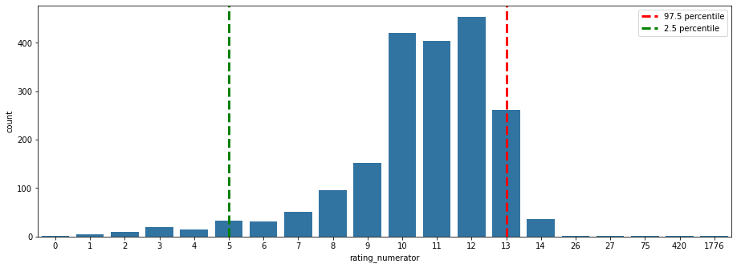

```python
# Identify upper and lower bounds for assumed outliers
lower = df_archive_clean["rating_numerator"].quantile(0.025)
upper = df_archive_clean["rating_numerator"].quantile(0.975)
txt= "95% of the tweets have ratings between {} and {}."
print(txt.format(lower,upper))

# Create a countplot to visually explore the distribution of irregular numerators
fig= plt.figure()
ax = fig.add_axes([.125, .125, 2, 1])
base_color = sns.color_palette()[0]
sns.countplot(data = df_archive_clean, x = "rating_numerator", color = base_color, ax = ax)

# Add vertical bars to show upper and lower bounds
ax.axvline(x = upper, label= "97.5 percentile", color = "r", linestyle='--', linewidth=3)
ax.axvline(x = lower, label= "2.5 percentile", color = "g", linestyle='--', linewidth=3)

ax.legend()
plt.show()
```

```python
txt = "{} ratings out of 1994 are outliers on the bottom low-end and {} are outliers on the high-end."
string1 = df_archive_clean.query('rating_numerator < 5').count()[0]
string2 = df_archive_clean.query('rating_numerator > 13').count()[0]
print(txt.format(string1, string2))
```

```
49 ratings out of 1994 are outliers on the bottom low-end and 41 are outliers on the high-end.
```

```python
# Isolate entries with irregular numerators and subset only the relevant columns for easier viewing
irr_numerator = df_archive_clean.query('(rating_numerator<5) or (rating_numerator>13)')[["name","text","rating_numerator", "rating_denominator"]]
irr_numerator = irr_numerator.sort_values(by="rating_numerator", ascending=False)
irr_numerator
```

|  | name | text | rating_numerator | rating_denominator |
| --- | --- | --- | --- | --- |
| 979 | Atticus | This is Atticus. He's quite simply America af.... | 1776 | 10 |
| 2074 | None | After so many requests... here you go.\n\nGood... | 420 | 10 |
| 695 | Logan | This is Logan, the Chow who lived. He solemnly... | 75 | 10 |
| 763 | Sophie | This is Sophie. She's a Jubilant Bush Pupper. ... | 27 | 10 |
| 1712 | None | Here we have uncovered an entire battalion of ... | 26 | 10 |
| ... | ... | ... | ... | ... |
| 1869 | None | What kind of person sends in a picture without... | 1 | 10 |
| 2091 | None | Flamboyant pup here. Probably poisonous. Won't... | 1 | 10 |
| 2338 | None | Not familiar with this breed. No tail (weird).... | 1 | 10 |
| 315 | None | When you're so blinded by your systematic plag... | 0 | 10 |
| 1016 | None | PUPDATE: can't see any. Even if I could, I cou... | 0 | 10 |

90 rows × 4 columns

**Note:** Here too I'll examine this more closely in a spreadsheet.

```python
# Extract table to a spreadsheet
irr_numerator.to_excel('irr_numerator.xlsx')
```

**Note:** After examining the spreadsheet, I could identify 3 issues within the **90 entries with irregular numerators**:

1. **2 entries** simply had irregular ratings
2. **3 entries** had misentered ratings because of decimal ratings like 9.75
3. **85 entries** were justified

**Cleaning method:** ** Here it made more sense to just quickly clean the entries within Excel and then reload the spreadsheet

1. The two entries here (1776 and 420) cannot be considered a correct rating so will change to median (11)
2. Will manually correct these
3. Will leave them as is

```python
# Read corrected spreadsheet to a dataframe
irr_numerator = pd.read_excel('irr_numerator_ok.xlsx', index_col=0)
irr_numerator
```

|  | name | text | rating_numerator | rating_denominator | new_rating_numerator |
| --- | --- | --- | --- | --- | --- |
| 979 | Atticus | This is Atticus. He's quite simply America af.... | 1776 | 10 | 11 |
| 2074 | None | After so many requests... here you go.\n\nGood... | 420 | 10 | 11 |
| 695 | Logan | This is Logan, the Chow who lived. He solemnly... | 75 | 10 | 10 |
| 763 | Sophie | This is Sophie. She's a Jubilant Bush Pupper. ... | 27 | 10 | 11 |
| 1712 | None | Here we have uncovered an entire battalion of ... | 26 | 10 | 11 |

```python
# Save the index of new ratings
new_rating_index = irr_numerator.index

# Only change the values at the new_rating_index using the values from irr_numerator
df_archive_clean.loc[new_rating_index, 'rating_numerator'] = irr_numerator.loc[new_rating_index, 'new_rating_numerator']
```

#### Issue #7b - Test

```python
df_archive_clean.loc[new_rating_index, ['rating_numerator','rating_denominator']]
```

|  | rating_numerator | rating_denominator |
| --- | --- | --- |
| 979 | 11 | 10 |
| 2074 | 11 | 10 |
| 695 | 10 | 10 |
| 763 | 11 | 10 |
| 1712 | 11 | 10 |

```python
# Should be 36 (41-5) outliers on the high end
txt = "{} ratings out of 1994 are outliers on the bottom low-end and {} are outliers on the high-end."
string1 = df_archive_clean.query('rating_numerator < 5').count()[0]
string2 = df_archive_clean.query('rating_numerator > 13').count()[0]
print(txt.format(string1, string2))
```

```
49 ratings out of 1994 are outliers on the bottom low-end and 36 are outliers on the high-end.
```

```python
# Postcleaning check
df_archive_clean[["rating_numerator", "rating_denominator"]].describe()
```

|  | rating_numerator | rating_denominator |
| --- | --- | --- |
| count | 1994.000000 | 1994.0 |
| mean | 10.555165 | 10.0 |
| std | 2.176648 | 0.0 |
| min | 0.000000 | 10.0 |
| 25% | 10.000000 | 10.0 |
| 50% | 11.000000 | 10.0 |
| 75% | 12.000000 | 10.0 |
| max | 14.000000 | 10.0 |

### Issue #8:

- df_archive: `timestamp` column is `object` Dtype

#### Issue #8 - Define:

- Change dtype of `timestamp` column to `datatime` using `to_datetime`

#### Issue #8 - Code

```python
# Precleaning check
df_archive_clean["timestamp"].dtypes
```

```
dtype('O')
```

```python
# Change dtype of `timestamp` column to `datatime` using `to_datetime`
df_archive_clean["timestamp"] = pd.to_datetime(df_archive_clean.timestamp)
```

#### Issue #8 - Test

```python
# Postcleaning check
df_archive_clean["timestamp"].dtypes
```

```
datetime64[ns, UTC]
```

### Issue #9:

- All columns, despite being numbers, are ‘object’ Dtype and the shared observation is labeled `tweet ID`|

#### Issue #9 - Define:

- Change dtype of `tweet ID`, `retweet count`, and `favorite count` to `int` using the `astype` function
- Rename `tweet ID` to `tweet_id` so that it matches the naming convention of the other tables

#### Issue #9 - Code

```python
# Precleaning check
df_tweets_clean.info()
```

```
<class 'pandas.core.frame.DataFrame'>
Int64Index: 2354 entries, 0 to 0
Data columns (total 3 columns):
 #   Column          Non-Null Count  Dtype
---  ------          --------------  -----
 0   tweet ID        2354 non-null   object
 1   retweet count   2354 non-null   object
 2   favorite count  2354 non-null   object
dtypes: object(3)
memory usage: 73.6+ KB
```

```python
# Change dtype of all columns to `int`
df_tweets_clean[['tweet ID','retweet count','favorite count']] = df_tweets_clean[['tweet ID','retweet count','favorite count']].astype("int")
```

```python
# Rename `tweet ID` to `tweet_id`
df_tweets_clean = df_tweets_clean.rename(columns = {"tweet ID":"tweet_id"})
```

#### Issue #9 - Test

```python
#  Postcleaning check
df_tweets_clean.info()
```

```
<class 'pandas.core.frame.DataFrame'>
Int64Index: 2354 entries, 0 to 0
Data columns (total 3 columns):
 #   Column          Non-Null Count  Dtype
---  ------          --------------  -----
 0   tweet_id        2354 non-null   int64
 1   retweet count   2354 non-null   int64
 2   favorite count  2354 non-null   int64
dtypes: int64(3)
memory usage: 73.6 KB
```

### Issue #10

- df_image: Has multiple image predictions when only one is necessary

#### Issue #10 - Define:

- Drop all columns except for `tweet_id`, `jpg_url`, and `p1`
- Rename 'p1' to 'breed'

**Note**: For the time being, all other image prediction data are beyond the scope of this project so should be dropped.

#### Issue #10 - Code

```python
#  Precleaning check
list(df_image_clean.columns)
```

```
['tweet_id',
 'jpg_url',
 'img_num',
 'p1',
 'p1_conf',
 'p1_dog',
 'p2',
 'p2_conf',
 'p2_dog',
 'p3',
 'p3_conf',
 'p3_dog']
```

```python
df_image_clean.head(3)
```

|  | tweet_id | jpg_url | img_num | p1 | p1_conf | p1_dog | p2 | p2_conf | p2_dog | p3 | p3_conf | p3_dog |
| --- | --- | --- | --- | --- | --- | --- | --- | --- | --- | --- | --- | --- |
| 0 | 666020888022790149 | https://pbs.twimg.com/media/CT4udn0WwAA0aMy.jpg | 1 | Welsh_springer_spaniel | 0.465074 | True | collie | 0.156665 | True | Shetland_sheepdog | 0.061428 | True |
| 1 | 666029285002620928 | https://pbs.twimg.com/media/CT42GRgUYAA5iDo.jpg | 1 | redbone | 0.506826 | True | miniature_pinscher | 0.074192 | True | Rhodesian_ridgeback | 0.072010 | True |
| 2 | 666033412701032449 | https://pbs.twimg.com/media/CT4521TWwAEvMyu.jpg | 1 | German_shepherd | 0.596461 | True | malinois | 0.138584 | True | bloodhound | 0.116197 | True |

```python
# Subset out unnecessary columns
df_image_clean = df_image_clean[['tweet_id', 'jpg_url', 'p1']]
```

```python
# Rename column
df_image_clean = df_image_clean.rename(columns = {"p1":"breed"})
```

#### Issue #10 - Test

```python
# Postcleaning check
list(df_image_clean.columns)
```

```
['tweet_id', 'jpg_url', 'breed']
```

```python
df_image_clean.head(3)
```

|  | tweet_id | jpg_url | breed |
| --- | --- | --- | --- |
| 0 | 666020888022790149 | https://pbs.twimg.com/media/CT4udn0WwAA0aMy.jpg | Welsh_springer_spaniel |
| 1 | 666029285002620928 | https://pbs.twimg.com/media/CT42GRgUYAA5iDo.jpg | redbone |
| 2 | 666033412701032449 | https://pbs.twimg.com/media/CT4521TWwAEvMyu.jpg | German_shepherd |

### Issue #1:

- df_archive: Variables as column headers (`doggo`, `flooder`, `pepper`, `puppy`)

#### Issue #1 - Define:

- Extract dog stage names in `text` and, if found, add them to a new column `dog_stages`

#### Issue #1 - Code

```python
# Precleaning check
df_archive_clean.columns
```

```
Index(['tweet_id', 'timestamp', 'text', 'expanded_urls', 'rating_numerator',
       'rating_denominator', 'name', 'doggo', 'floofer', 'pupper', 'puppo'],
      dtype='object')
```

```python
# Extract dog stage names in `text` and, if found, add them to a new column `dog_stages`
df_archive_clean['dog_stages'] = df_archive_clean.text.str.extract('(doggo|floofer|pupper|puppo)', expand = True)
```

*Reference*: https://knowledge.udacity.com/questions/111929

```python
# Drop unnecessary columns
df_archive_clean.drop(['doggo','floofer','pupper','puppo'], axis=1, inplace = True)
```

#### Issue #1 - Test

```python
# Postcleaning check
df_archive_clean.columns
```

```
Index(['tweet_id', 'timestamp', 'text', 'expanded_urls', 'rating_numerator',
       'rating_denominator', 'name', 'dog_stages'],
      dtype='object')
```

```python
df_archive_clean.head(3)
```

|  | tweet_id | timestamp | text | expanded_urls | rating_numerator | rating_denominator | name | dog_stages |
| --- | --- | --- | --- | --- | --- | --- | --- | --- |
| 0 | 892420643555336193 | 2017-08-01 16:23:56+00:00 | This is Phineas. He's a mystical boy. Only eve... | https://twitter.com/dog_rates/status/892420643... | 13 | 10 | Phineas | NaN |
| 1 | 892177421306343426 | 2017-08-01 00:17:27+00:00 | This is Tilly. She's just checking pup on you.... | https://twitter.com/dog_rates/status/892177421... | 13 | 10 | Tilly | NaN |
| 2 | 891815181378084864 | 2017-07-31 00:18:03+00:00 | This is Archie. He is a rare Norwegian Pouncin... | https://twitter.com/dog_rates/status/891815181... | 12 | 10 | Archie | NaN |

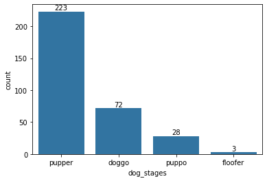

```python
stage_count = df_archive_clean.dog_stages.value_counts()
sns.countplot(data=df_archive_clean, x='dog_stages', order=stage_count.index, color = base_color);

# Print value on each bar
for i in range (stage_count.shape[0]):
    count = stage_count[i]
    plt.text(i, count+11, count, ha = 'center', va='top')
```

### Issue #2:

- `df_tweets` + `df_image`: Share same observational unit as `df_archive` so they don't need to be separate dataframes

#### Issue #2 - Define:

- Merge `df_tweets_clean` to `df_archive_clean` to create `df_master`
- Merge `df_image_clean` to `df_master`

#### Issue #2 - Code

```python
# Merge dfs to create `df_master`

df_master = pd.merge(df_archive_clean, df_tweets_clean, how="inner", on = "tweet_id")
df_master = pd.merge(df_master, df_image_clean, how="inner", on = "tweet_id")
df_master.reset_index(drop=True, inplace=True)
```

#### Issue #2 - Test

```python
# Confirm
df_master.info()
```

```
<class 'pandas.core.frame.DataFrame'>
RangeIndex: 1994 entries, 0 to 1993
Data columns (total 12 columns):
 #   Column              Non-Null Count  Dtype
---  ------              --------------  -----
 0   tweet_id            1994 non-null   int64
 1   timestamp           1994 non-null   datetime64[ns, UTC]
 2   text                1994 non-null   object
 3   expanded_urls       1994 non-null   object
 4   rating_numerator    1994 non-null   int64
 5   rating_denominator  1994 non-null   int64
 6   name                1994 non-null   object
 7   dog_stages          326 non-null    object
 8   retweet count       1994 non-null   int64
 9   favorite count      1994 non-null   int64
 10  jpg_url             1994 non-null   object
 11  breed               1994 non-null   object
dtypes: datetime64[ns, UTC](1), int64(5), object(6)
memory usage: 187.1+ KB
```

```python
# Confirm
df_master.describe()
```

|  | tweet_id | rating_numerator | rating_denominator | retweet count | favorite count |
| --- | --- | --- | --- | --- | --- |
| count | 1.994000e+03 | 1994.000000 | 1994.0 | 1994.000000 | 1994.000000 |
| mean | 7.358508e+17 | 10.555165 | 10.0 | 2766.753260 | 8895.725677 |
| std | 6.747816e+16 | 2.176648 | 0.0 | 4674.698447 | 12213.193181 |
| min | 6.660209e+17 | 0.000000 | 10.0 | 16.000000 | 81.000000 |
| 25% | 6.758475e+17 | 10.000000 | 10.0 | 624.750000 | 1982.000000 |
| 50% | 7.084748e+17 | 11.000000 | 10.0 | 1359.500000 | 4136.000000 |
| 75% | 7.877873e+17 | 12.000000 | 10.0 | 3220.000000 | 11308.000000 |
| max | 8.924206e+17 | 14.000000 | 10.0 | 79515.000000 | 132810.000000 |

```python
# Confirm
df_master.head(3)
```

|  | tweet_id | timestamp | text | expanded_urls | rating_numerator | rating_denominator | name | dog_stages | retweet count | favorite count | jpg_url | breed |
| --- | --- | --- | --- | --- | --- | --- | --- | --- | --- | --- | --- | --- |
| 0 | 892420643555336193 | 2017-08-01 16:23:56+00:00 | This is Phineas. He's a mystical boy. Only eve... | https://twitter.com/dog_rates/status/892420643... | 13 | 10 | Phineas | NaN | 8853 | 39467 | https://pbs.twimg.com/media/DGKD1-bXoAAIAUK.jpg | orange |
| 1 | 892177421306343426 | 2017-08-01 00:17:27+00:00 | This is Tilly. She's just checking pup on you.... | https://twitter.com/dog_rates/status/892177421... | 13 | 10 | Tilly | NaN | 6514 | 33819 | https://pbs.twimg.com/media/DGGmoV4XsAAUL6n.jpg | Chihuahua |
| 2 | 891815181378084864 | 2017-07-31 00:18:03+00:00 | This is Archie. He is a rare Norwegian Pouncin... | https://twitter.com/dog_rates/status/891815181... | 12 | 10 | Archie | NaN | 4328 | 25461 | https://pbs.twimg.com/media/DGBdLU1WsAANxJ9.jpg | Chihuahua |

## 4. Storing Data

Save gathered, assessed, and cleaned master dataset to a CSV file named "twitter_archive_master.csv".

```python
df_master.to_csv("twitter_archive_master.csv")
```

## 5. Analyzing and Visualizing Data

### 5.1 Insights:

1. What is the most retweeted tweet?
2. What is the most common rating?
3. What are the most common breeds found by the neural network?

```python
# 1. What is the most retweeted tweet?
most_retweeted = df_master[df_master["retweet count"] == df_master["retweet count"].max()]
most_retweeted
```

|  | tweet_id | timestamp | text | expanded_urls | rating_numerator | rating_denominator | name | dog_stages | retweet count | favorite count | jpg_url | breed |
| --- | --- | --- | --- | --- | --- | --- | --- | --- | --- | --- | --- | --- |
| 775 | 744234799360020481 | 2016-06-18 18:26:18+00:00 | Here's a doggo realizing you can stand in a po... | https://twitter.com/dog_rates/status/744234799... | 13 | 10 | None | doggo | 79515 | 131075 | https://pbs.twimg.com/ext_tw_video_thumb/74423... | Labrador_retriever |

```python
list(most_retweeted["expanded_urls"])
```

```
['https://twitter.com/dog_rates/status/744234799360020481/video/1']
```

[figure not shown]

```python
from IPython.display import Image
Image(filename='most_retweeted.png', width=500)
```

```python
list(most_retweeted["jpg_url"])[0]
```

```
'https://pbs.twimg.com/ext_tw_video_thumb/744234667679821824/pu/img/1GaWmtJtdqzZV7jy.jpg'
```

**Answer**: The most retweeted tweet is tweet_id `744234799360020481' which features the following very good boy.

[figure not shown]

```python
# 2. What is the most common rating?
common_rating = df_master["rating_numerator"].value_counts(normalize=True)
common_rating[:5]
```

```
12    0.227683
10    0.211635
11    0.204614
13    0.131394
9     0.076229
Name: rating_numerator, dtype: float64
```

**Answer**: The most common rating is 12/10

```python
# 3. What are the most common breeds found by the neural network?
common_breeds = df_master["breed"].value_counts()
common_breeds[:5]
```

```
golden_retriever      139
Labrador_retriever     95
Pembroke               88
Chihuahua              79
pug                    54
Name: breed, dtype: int64
```

**Answer**: In order, the most common breeds identified by the neural network are Golden Retriever, Labrador Retriever, Pembroke, Chihuahua, and Pug.

```python
# Code for Act_Report for image URLs for each dog breed

list(df_master[df_master["breed"] == "pug"]["jpg_url"])[0]
list(df_master[df_master["breed"] == "Chihuahua"]["jpg_url"])[0]
list(df_master[df_master["breed"] == "Pembroke"]["jpg_url"])[0]
list(df_master[df_master["breed"] == "Labrador_retriever"]["jpg_url"])[0]
list(df_master[df_master["breed"] == "golden_retriever"]["jpg_url"])[0]
```

```
'https://pbs.twimg.com/media/DFg_2PVW0AEHN3p.jpg'
```

### 5.2 Visualization

- What is the average retweet count for each rating?

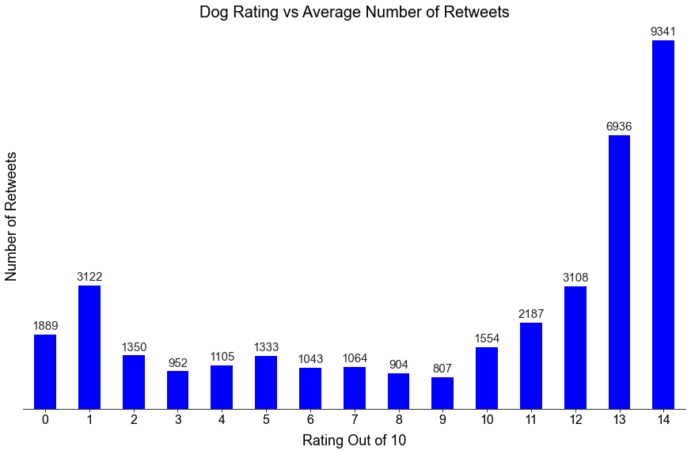

```python
rating_mean = df_master.groupby("rating_numerator")["retweet count"].mean()

# Plot the results of movie_stats_total
plt.figure(figsize = (15,9))
rating_mean.plot.bar(color="b")

# Set base style
sns.set_style("white")
sns.despine(top=True,
           right=True,
           left=True)

# Print value on each bar
for i in range (rating_mean.shape[0]):
    count = int(rating_mean[i])
    plt.text(i, count+350, count, ha = 'center', va='top', size=15)

# Customize plot title and labels
plt.title("Dog Rating vs Average Number of Retweets", size=20)
plt.xlabel('Rating Out of 10', fontsize=18, labelpad= 10, color="black")
plt.ylabel('Number of Retweets', fontsize=18, color="black")
plt.xticks(fontsize=16)
plt.xticks(rotation=0, fontsize=16)
plt.yticks(ticks=[])
#plt.yticks(fontsize=16)

# Save figure
plt.savefig("Dog Rating vs Average Number of Retweets")

# Show figure
plt.show()
```

### Extra, unused visualizations

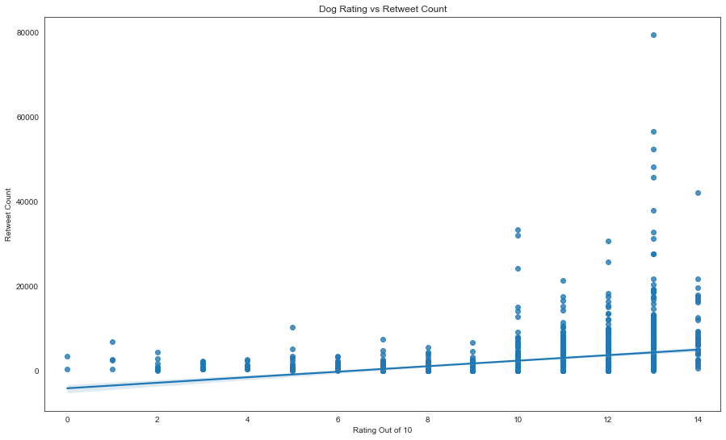

```python
import seaborn as sns
import scipy.stats

fig, ax = plt.subplots(figsize=(15,9))

sns.set()

sns.regplot(x ="rating_numerator",
            y ="retweet count",
            data = df_master,
           ax = ax)

ax.set(xlabel="Rating Out of 10",
       xlim= (-0.5,14.5),
      ylabel= "Retweet Count",
      title= "Dog Rating vs Retweet Count")

plt.show()
```

```
dog_stages        doggo  floofer  pupper  puppo
rating_numerator
3                     0        0       2      0
5                     1        0       1      0
6                     0        0       3      0
7                     0        0       8      0
8                     4        0      13      0
9                     0        0      17      1
10                    6        0      50      3
11                   21        0      58      2
12                   16        1      52      8
13                   18        2      12     13
14                    6        0       7      1
```

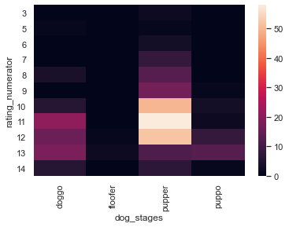

```python
pd_crosstab = pd.crosstab(df_master["rating_numerator"], df_master["dog_stages"])
print(pd_crosstab)

# Plot a heatmap of the table
sns.heatmap(pd_crosstab)

# Rotate tick marks for visibility
plt.yticks(rotation=0)
plt.xticks(rotation=90)

plt.show()
```

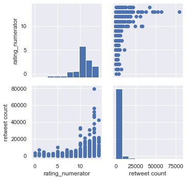

```python
g = sns.PairGrid(df_master, vars=["rating_numerator","retweet count"])
g = g.map_diag(plt.hist)
g = g.map_offdiag(plt.scatter)
```

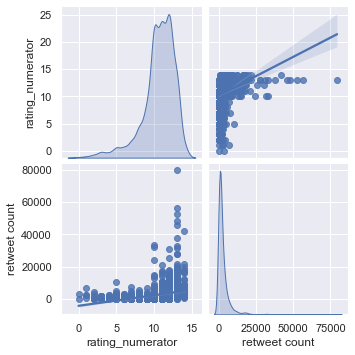

```python
sns.pairplot(data=df_master,
             vars=["rating_numerator","retweet count"],
             kind='reg',
             palette='BrBG',
             diag_kind = 'kde')

plt.show()
plt.clf()
```

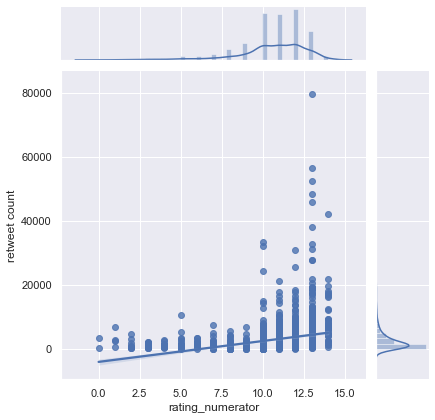

```python
g = sns.JointGrid(data=df_master, x="rating_numerator",
y="retweet count")
g.plot(sns.regplot, sns.distplot)
```

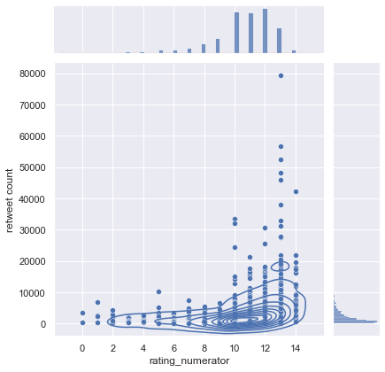

```python
import scipy.stats as stats

g = sns.jointplot(data=df_master, x="rating_numerator",
y="retweet count")
g = g.plot_joint(sns.kdeplot)
g = g.plot_marginals(sns.kdeplot, shade=True)
```

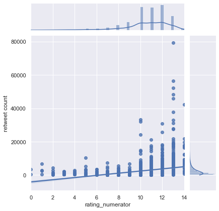

```python
sns.jointplot(x="rating_numerator",
        y="retweet count",
        kind='reg',
        data=df_master)

plt.show()
plt.clf()
```

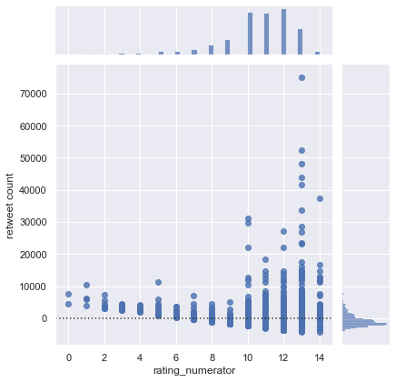

```python
sns.jointplot(x="rating_numerator",
        y="retweet count",
        kind='resid',
        data=df_master)

plt.show()
plt.clf()
```

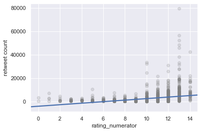

```python
sns.regplot(x = 'rating_numerator',
            y = 'retweet count',
            # Set scatter point opacity & color
            scatter_kws = {'alpha':0.2, 'color':'gray'},
            # Disable confidence band
            ci = False,
            truncate=False,
            data = df_master)

plt.show()
```

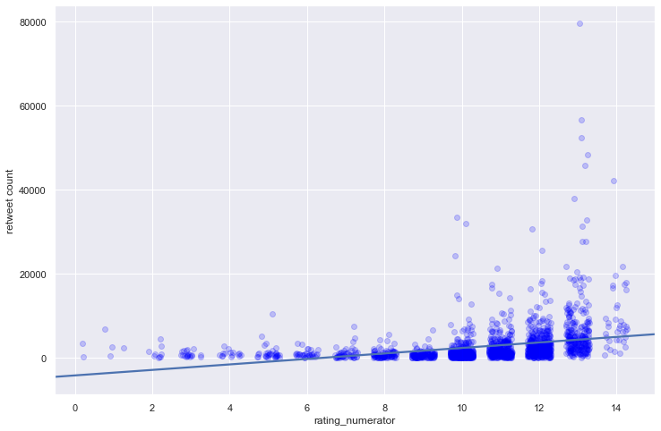

```python
plt.figure(figsize=[12,8])

sns.regplot(x = 'rating_numerator',
            y = 'retweet count',
            # Set scatter point opacity & color
            scatter_kws = {'alpha':0.2, 'color':'blue'},
            # Disable confidence band
            ci = False,
            truncate=False,
            x_jitter=0.3,
            data = df_master)

plt.show()
```

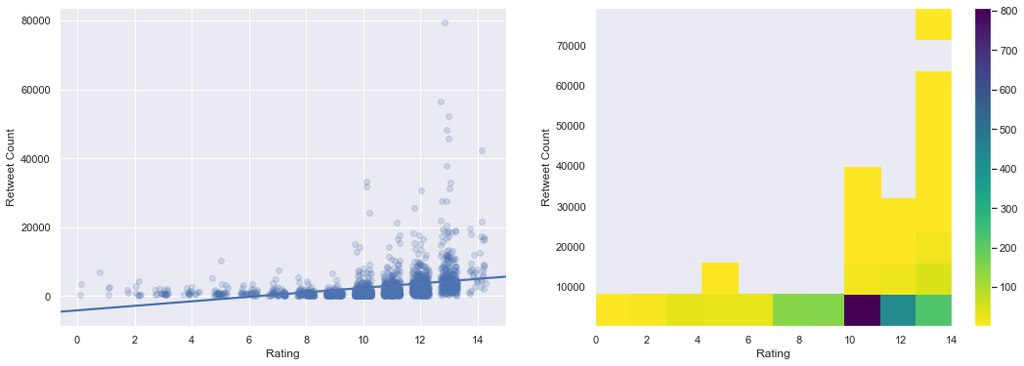

```python
# Example 1. Default heat plot using Matplotlib.pyplot.hist2d() function

plt.figure(figsize=[18, 6])

# Plot on left
plt.subplot(1, 2, 1)
sns.regplot(x = 'rating_numerator',
            y = 'retweet count',
            # Set scatter point opacity & color
            scatter_kws = {'alpha':0.2},
            # Disable confidence band
            ci = False,
            truncate=False,
            x_jitter=0.3,
            data = df_master)
plt.xlabel("Rating")
plt.ylabel("Retweet Count")

# Plot on right
plt.subplot(1, 2, 2)
plt.hist2d(data = df_master,
           x = 'rating_numerator',
           y = 'retweet count', cmin=0.5, cmap='viridis_r')
plt.colorbar()
plt.xlabel("Rating")
plt.ylabel("Retweet Count");
```

```python
df_master[["rating_numerator", "retweet count"]].describe()
```

|  | rating_numerator | retweet count |
| --- | --- | --- |
| count | 1994.000000 | 1994.000000 |
| mean | 10.555165 | 2766.753260 |
| std | 2.176648 | 4674.698447 |
| min | 0.000000 | 16.000000 |
| 25% | 10.000000 | 624.750000 |
| 50% | 11.000000 | 1359.500000 |
| 75% | 12.000000 | 3220.000000 |
| max | 14.000000 | 79515.000000 |

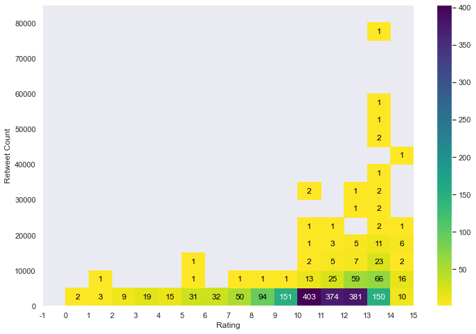

```python
import numpy as np
plt.figure(figsize=[12,8])
bins_x= np.arange(-1, 14+2, 1)
bins_y= np.arange(-1, 80000+5000, 5000)
ticks = bins_x
labels= ('{}'.format(x) for x in ticks)
h2d=plt.hist2d(data = df_master,
           x = 'rating_numerator',
           y = 'retweet count', cmin=0.5, cmap='viridis_r',
          bins=[bins_x, bins_y])
plt.colorbar()
plt.xlabel("Rating")
plt.ylabel("Retweet Count")
plt.xticks(ticks=bins_x, labels=labels);

# Select the bi-dimensional histogram, a 2D array of samples x and y.
# Values in x are histogrammed along the first dimension and
# values in y are histogrammed along the second dimension.
counts = h2d[0]

# Add text annotation on each cell
# Loop through the cell counts and add text annotations for each
for i in range(counts.shape[0]):
    for j in range(counts.shape[1]):
        c = counts[i,j]
        if c >= 100: # increase visibility on darker cells
            plt.text(bins_x[i]+0.5, bins_y[j]+2500, int(c),
                     ha = 'center', va = 'center', color = 'white')
        elif c > 0:
            plt.text(bins_x[i]+0.5, bins_y[j]+2500, int(c),
                     ha = 'center', va = 'center', color = 'black')
```